# Exploratory Data Analysis Project 2

# This is the final project for “Exploratory Data Analysis”

The case study we are doing is to examine the emissions of PM2.5 across year 1999~ 2008 within US, looking for specific city such as Baltimore, LA, and also looking for specific type, such as On-road, off-road.

This case study not only help me understand how to initiate a basic exploratory data analysis, but also assist me review all of the previous lecture related to basic R programming.

**The following is the basic skill included in this case study:**

1. Basic plotting system
2. Basic ggplot plotting system
3. Subsetting with various conditions
4. grepl: Grasping for specific text and returing a factor(condition to apply to your origianl data set)
5. tapply: applying function to a variable grouping by a factor, returing a numeric vector
6. aggregate: applying function to a variable grouping by a list, returing a data frame

```r
#Basic: Reading data and setting working directory
library(ggplot2)
NEI <- readRDS("/Users/andrewhu/Documents/GitHub/Coursera_DataScience_JHU/Exploratory Data Analysis/summarySCC_PM25.rds")
SCC <- readRDS("/Users/andrewhu/Documents/GitHub/Coursera_DataScience_JHU/Exploratory Data Analysis/Source_Classification_Code.rds")
```

Question 2:

Have total emissions from PM2.5 decreased in the Baltimore City, Maryland (fips==“24510”) from 1999 to 2008? Use the base plotting system to make a plot answering this question.

Solution: We need to subset a data set from the original data, with only the Baltimore City, and then we use the same tapply function to return a numeric vector with total emissions by each year.

```r
#Subset for BA
NEIBA <- subset(NEI, fips=="24510")

#Calculation and Plot
Emi_over_year_BA <- with(NEIBA, tapply(Emissions, year, sum, na.rm=TRUE))
str(Emi_over_year_BA)#note: the sturcture is a numeric vector
```

```
##  num [1:4(1d)] 3274 2454 3091 1862
##  - attr(*, "dimnames")=List of 1
##   ..$ : chr [1:4] "1999" "2002" "2005" "2008"
```

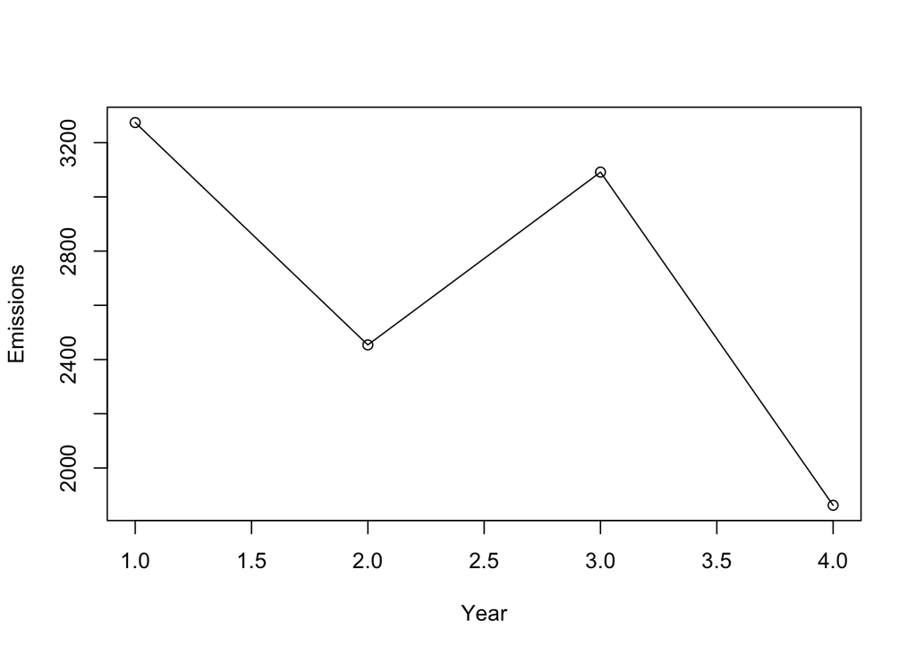

```r
plot(Emi_over_year_BA, type="o", xlab= "Year", ylab= "Emissions")
```

Question 3:

Of the four types of sources indicated by the type (point, nonpoint, onroad, nonroad) variable, which of these four sources have seen decreases in emissions from 1999–2008 for Baltimore City? Which have seen increases in emissions from 1999–2008? Use the ggplot2 plotting system to make a plot answer this question.

Solution: Now we want to examine four types of sources within Baltimore city. First, we need to use the aggregate function, to return a data frame that has three variables we are interested: Type, year and Emissions.

**Structure for aggregate function:** aggregate(df with a specific var you want to calculate, list of factor variables, function)

**Structure for ggplot:** Basic: ggplot(df, aes(x,y)) Addings: geom_point(), geom_bar(stat= “identity”).. Categorize: facet_grid(.~ the factor)

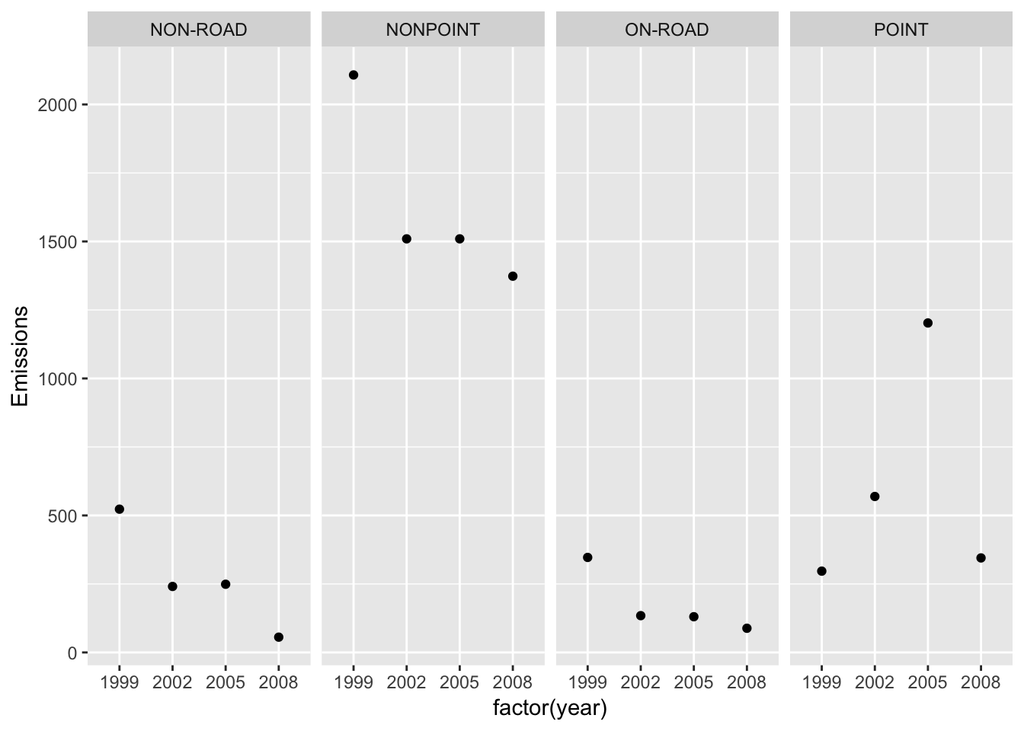

```r
#Subset a df: sum for Emissions, by type and by year
Emi_over_year_BA_df <- aggregate(NEIBA[c("Emissions")], list(type= NEIBA$type, year= NEIBA$year), sum )

##ggplot

#base
g<- ggplot(Emi_over_year_BA_df, aes(factor(year),Emissions) )

#
g + geom_point()+ facet_grid(. ~type)
```

Question 4: Across the United States, how have emissions from coal combustion-related sources changed from 1999–2008?

Solution: We need to “grasp” the text that contains “coal” at the source data “SCC” first, and then apply that condition to our original NEI data set. The hardest part would be how to search for the text and return the subsetted data frame.

**Structure for grepl:**

grepl(“the patent”, df$var where you want to grab)

By doing above, it will return a logical vector, indicating TRUE or FALSE.

You can apply the logical vector: factor <- df[grepl(“the patent”, df$var where you want to grab), df’s column]

Now, using the factor above as condition, and subset from the origina data set. subset<- origianl df [df$ var %in% factor, ] Now the subset contains all the rows that are matched with your factor

To sum up:

1. Grasp the text and return a factor
2. Apply factor to origianl data set and create a subset
3. Return a aggregated data frame
4. Plot

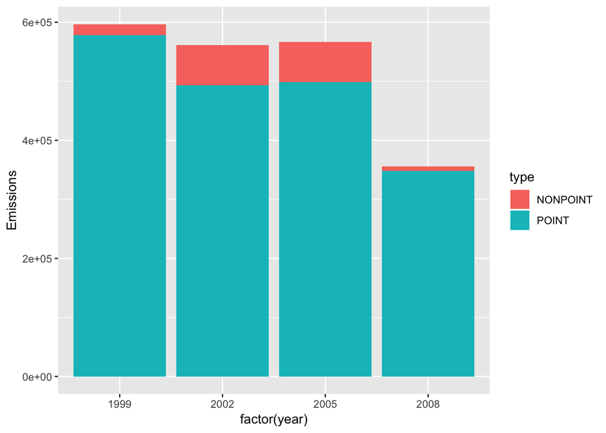

```r
coal <- SCC[grepl("Coal",SCC$Short.Name),"SCC" ]

NEI.sub <- NEI[NEI$SCC %in% coal,]

NEI.coal <- aggregate(NEI.sub[c("Emissions")], list(type= NEI.sub$type, year= NEI.sub$year), sum )
##ggplot

#base
g<- ggplot(NEI.coal, aes(x= factor(year),y= Emissions, fill=type))
#
g + geom_bar(stat= "identity")
```

Question 6: Compare emissions from motor vehicle sources in Baltimore City with emissions from motor vehicle sources in Los Angeles County, California (fips==“06037”). Which city has seen greater changes over time in motor vehicle emissions?

Solution: Simply plot BA / LA and compare. I use basic plotting system so as to set plotting parameters to plot two column at once.

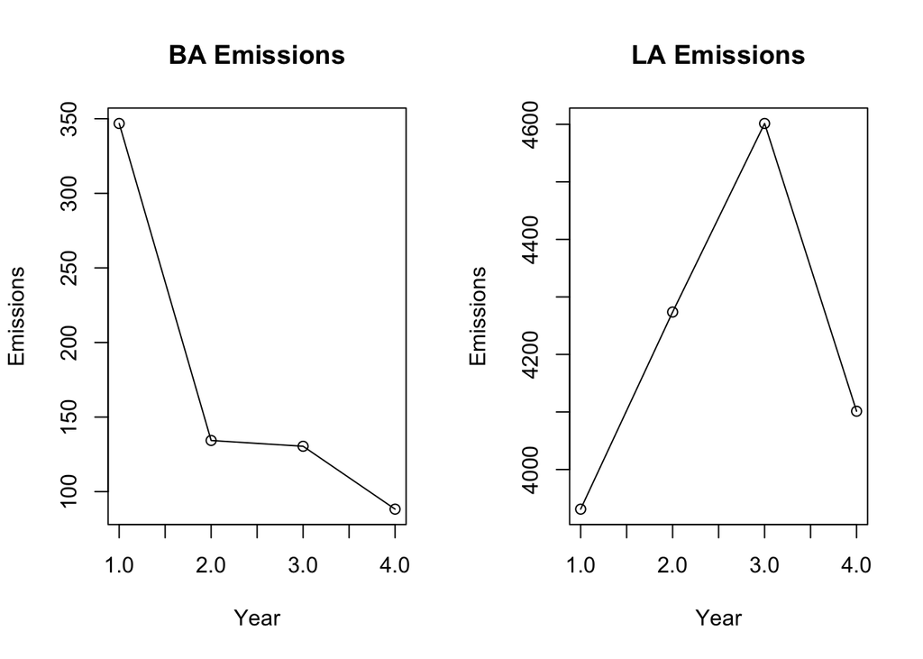

```r
NEIBAONROAD <- subset(NEI, fips=="24510" & type == "ON-ROAD")
NEILAONROAD <- subset(NEI, fips=="06037" & type == "ON-ROAD")


par(mfrow=c(1,2))

ba <- with(NEIBAONROAD, tapply(Emissions, year, sum, na.rm= TRUE))
la <- with(NEILAONROAD, tapply(Emissions, year, sum, na.rm= TRUE))


plot(ba, type ="o", xlab="Year", ylab= "Emissions", main="BA Emissions")
plot(la, type ="o", xlab="Year", ylab= "Emissions", main= "LA Emissions")
```